# 3190 Orden ETU/258/2017, de 24 de marzo, por la que se establecen las obligaciones de aportación al Fondo Nacional de Eficiencia Energética en el año 2017.

[Orden ETU/258/2017](http://www.boe.es/boe/dias/2017/03/25/pdfs/BOE-A-2017-3190.pdf)

La Directiva 2012/27/UE del Parlamento Europeo y del Consejo, de 25 de octubre de 2012, relativa a la eficiencia energética (en adelante la Directiva), por la que se modifican

las Directivas 2009/125/CE y 2010/30/UE, y por la que se derogan las Directivas 2004/8/CE y 2006/32/CE, crea un marco común para fomentar la eficiencia energética dentro de la Unión y establece acciones concretas a fin de alcanzar un notable ahorro de energía acumulado en el periodo 2014 - 2020.

La Directiva establece en su artículo 7 la obligación de justificar, por parte de cada Estado miembro, una cantidad de ahorro de energía acumulado para el periodo 20142020. En cumplimiento de esta obligación, España ha comunicado a la Comisión Europea un objetivo de 15.320 ktep, objetivo que se ha incrementado hasta los 15.979 ktep según la última revisión de la metodología realizada por la Comisión Europea

```r
library(ggplot2)
library(scales)
library(readxl)
fn<-read.csv("FNEE2017.csv")
fn$Sujeto<-factor(fn$Sujeto)
```

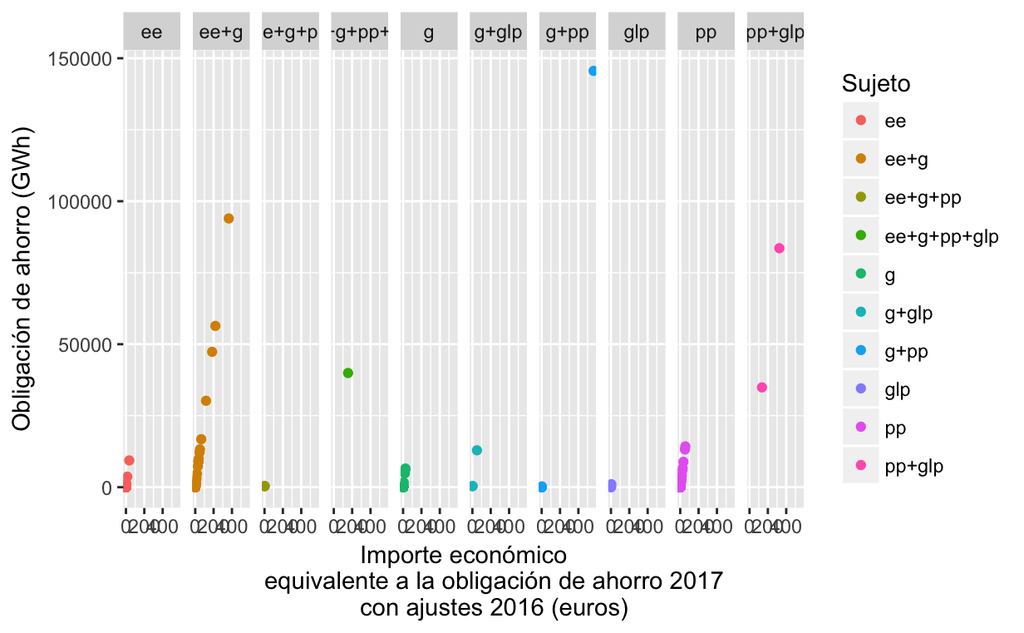

```r
p<-qplot(Obli_ahoGWh,GWh_15, data=fn, colour= Sujeto, ylab = ("Obligación de ahorro (GWh)"), xlab="Importe económico
         equivalente a la obligación de ahorro 2017
         con ajustes 2016 (euros)")
p + facet_grid(. ~ Sujeto)
```

```r
# p + scale_x_discrete(labels = NULL )+ scale_y_discrete(labels = NULL)
```

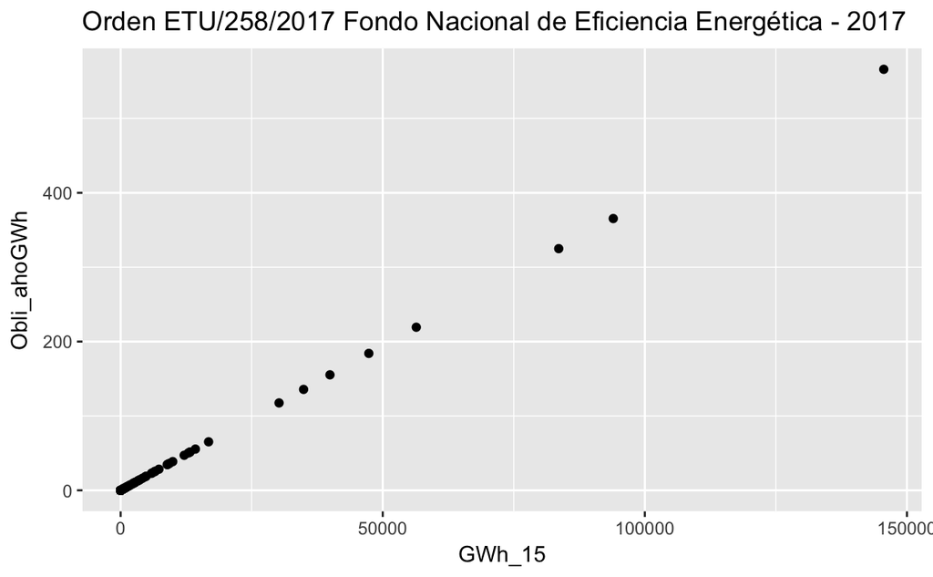

```r
p <- ggplot(fn, aes(GWh_15, Obli_ahoGWh)) + geom_point()
p +  labs(title = "Orden ETU/258/2017 Fondo Nacional de Eficiencia Energética - 2017")
```

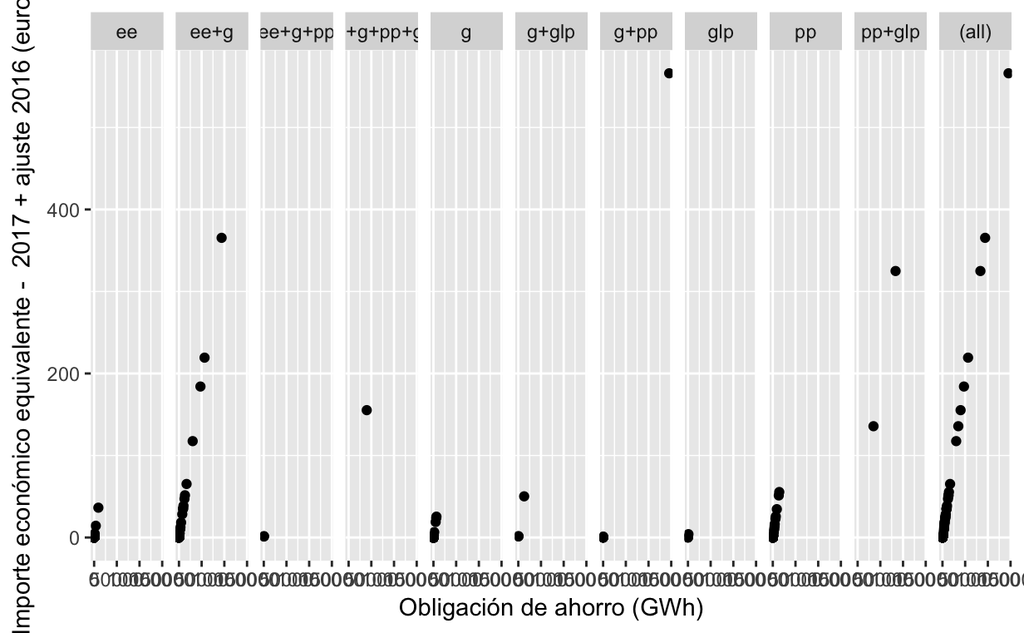

```r
p+ xlab("Obligación de ahorro (GWh)") + ylab("Importe económico equivalente -  2017 + ajuste 2016 (euros)") + facet_grid(. ~ Sujeto,margins=TRUE)
```

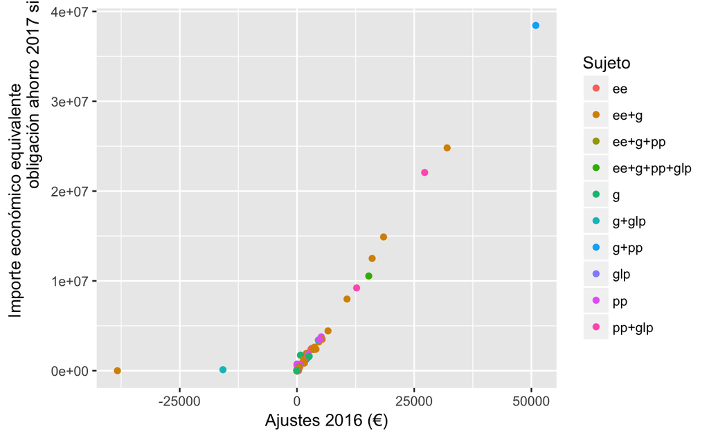

```r
p<-qplot(Ajus_16,IEEoa_17_EUR, data=fn, colour= Sujeto, ylab = ("Importe económico equivalente
                                                                obligación ahorro 2017 sin ajustes (€)"), xlab="Ajustes 2016 (€)")
p
```

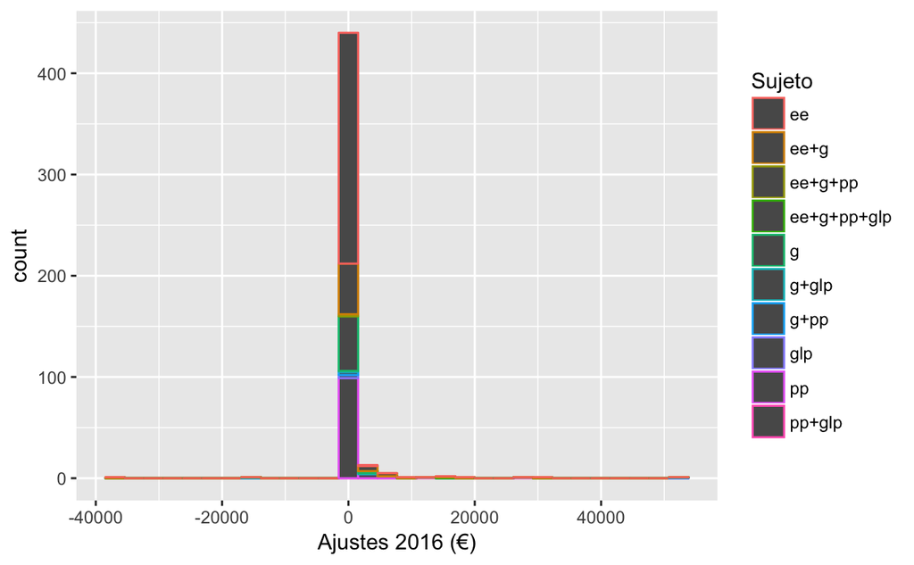

```r
p<-qplot(Ajus_16,data=fn, colour= Sujeto, xlab="Ajustes 2016 (€)", bins=30)
p
```

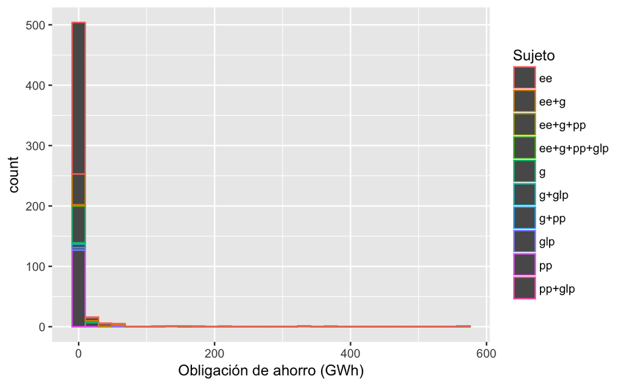

```r
p<-qplot(Obli_ahoGWh,data=fn, colour= Sujeto, xlab="Obligación de ahorro (GWh)", bins=30)
p
```

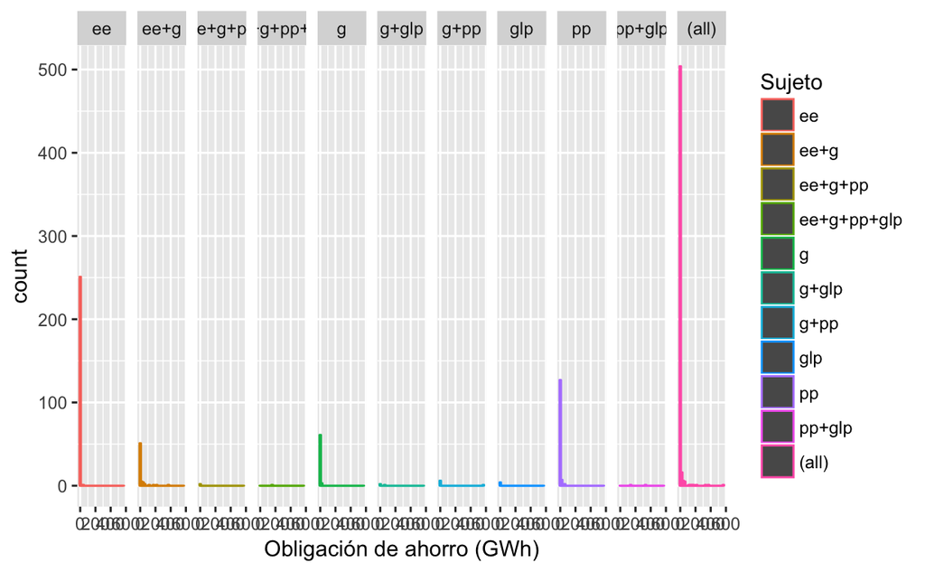

```r
p<-qplot(Obli_ahoGWh,data=fn, colour= Sujeto, xlab="Obligación de ahorro (GWh)", bins=30)
p +  facet_grid(. ~ Sujeto,margins=TRUE)
```

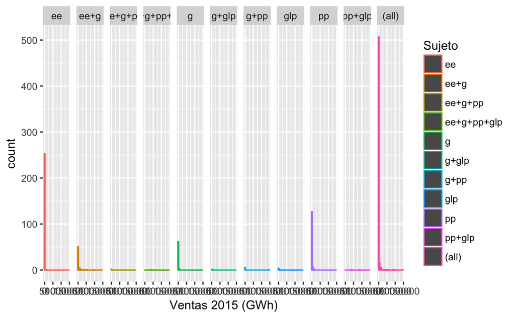

```r
p<-qplot(GWh_15,data=fn, colour= Sujeto, xlab="Ventas 2015 (GWh)", bins=30)
p +  facet_grid(. ~ Sujeto,margins=TRUE)
```

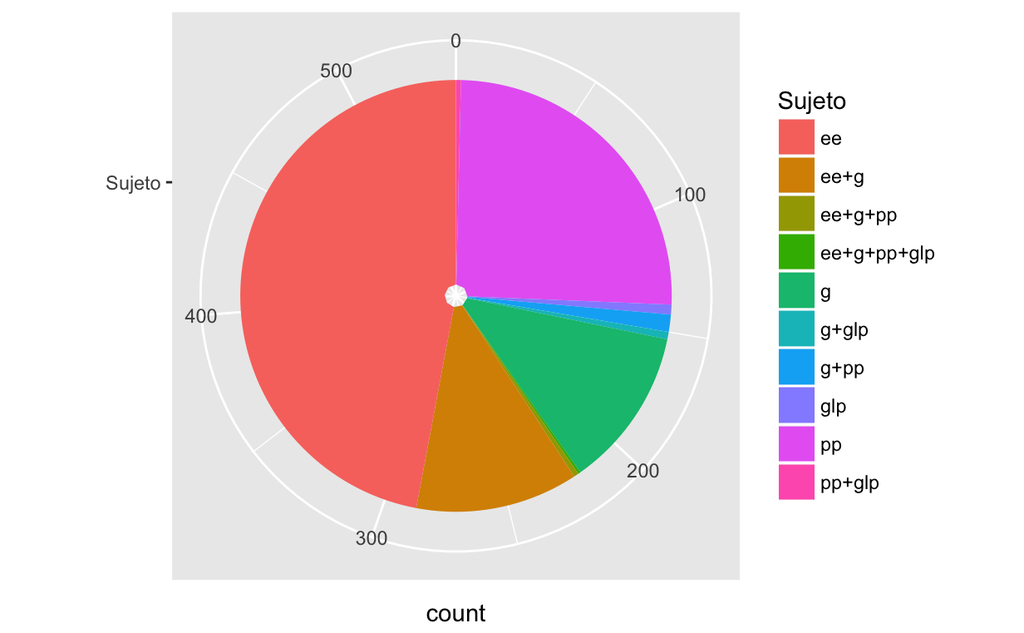

```r
ggplot(fn,
       aes(x = factor("Sujeto"), fill = Sujeto) ) +
        geom_bar() +
        coord_polar(theta = "y") +
        scale_x_discrete("")
```

```r
fn$GWh_15<-factor(fn$GWh_15)
```

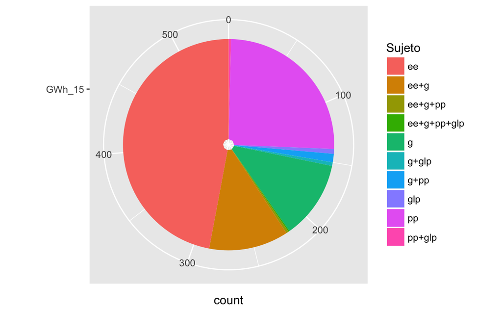

```r
ggplot(fn,
       aes(x = factor("GWh_15"), fill = Sujeto) ) +
        geom_bar() +
        coord_polar(theta = "y") +
        scale_x_discrete("")
```

Copyleft Antonio Maudes